# Practica4

**Escribimos un primer mensaje para mostrar en pantalla**

```python
print(" ¡Hola,mundo!")
```

```
 ¡Hola,mundo!
```

**Importamos la librería que vamos a usar, pandas, y utilizamos la asignación 'as'para llamarlo simplemente pd a lo largo de todo el proceso y no tener que escribir 'pandas' cada vez**

```python
import pandas as pd
```

**Primer hemos descargado la base de datos y la hemos subido a Github para tener siempre acceso a ella (para ello hemos añadido ?raw=true al final del link para poder leerlo con pandas). No obstante, podríamos haber llamado directamente al link**

```python
url='https://github.com/Alejandraa98/practicas-periodismo-de-datos/blob/main/practica-4.csv?raw=true'
```

**Leemos la base de datos a partir del URL especificando los delimitadores y la asignamos a la variable df**

```python
df = pd.read_csv(url,delimiter= ';')
```

**Escribiendo df podemos acceder al contenido de esa base de datos, en este caso expresada a través de la tabla**

```python
df
```

|  | Sexo | Ciclo | Nivel de formación más apropiado para realizar su trabajo | Total |
| --- | --- | --- | --- | --- |
| 0 | Ambos sexos | Total | Total trabajando | 90.506 |
| 1 | Ambos sexos | Total | Título universitario | 17.969 |
| 2 | Ambos sexos | Total | Formación profesional de grado superior | 46.756 |
| 3 | Ambos sexos | Total | Formación profesional de grado medio / bachill... | 11.386 |
| 4 | Ambos sexos | Total | Formación profesional básica | 3.760 |
| ... | ... | ... | ... | ... |
| 1318 | Mujeres | 15 - VIDRIO Y CERÁMICA 16 - MADERA, MUEBLE Y C... | Formación profesional de grado superior | 100.000 |
| 1319 | Mujeres | 15 - VIDRIO Y CERÁMICA 16 - MADERA, MUEBLE Y C... | Formación profesional de grado medio / bachill... | 25.000 |
| 1320 | Mujeres | 15 - VIDRIO Y CERÁMICA 16 - MADERA, MUEBLE Y C... | Formación profesional básica | 13.000 |
| 1321 | Mujeres | 15 - VIDRIO Y CERÁMICA 16 - MADERA, MUEBLE Y C... | ESO, EGB, etc ... | 47.000 |
| 1322 | Mujeres | 15 - VIDRIO Y CERÁMICA 16 - MADERA, MUEBLE Y C... | No consta | 5.000 |

1323 rows × 4 columns

**Mediante las funciones head y tail podemos visualizar la parte superior e inferior de los datos respectivamente**

```python
df.head()
```

|  | Sexo | Ciclo | Nivel de formación más apropiado para realizar su trabajo | Total |
| --- | --- | --- | --- | --- |
| 0 | Ambos sexos | Total | Total trabajando | 90.506 |
| 1 | Ambos sexos | Total | Título universitario | 17.969 |
| 2 | Ambos sexos | Total | Formación profesional de grado superior | 46.756 |
| 3 | Ambos sexos | Total | Formación profesional de grado medio / bachill... | 11.386 |
| 4 | Ambos sexos | Total | Formación profesional básica | 3.760 |

```python
df.tail()
```

|  | Sexo | Ciclo | Nivel de formación más apropiado para realizar su trabajo | Total |
| --- | --- | --- | --- | --- |
| 1318 | Mujeres | 15 - VIDRIO Y CERÁMICA 16 - MADERA, MUEBLE Y C... | Formación profesional de grado superior | 100.0 |
| 1319 | Mujeres | 15 - VIDRIO Y CERÁMICA 16 - MADERA, MUEBLE Y C... | Formación profesional de grado medio / bachill... | 25.0 |
| 1320 | Mujeres | 15 - VIDRIO Y CERÁMICA 16 - MADERA, MUEBLE Y C... | Formación profesional básica | 13.0 |
| 1321 | Mujeres | 15 - VIDRIO Y CERÁMICA 16 - MADERA, MUEBLE Y C... | ESO, EGB, etc ... | 47.0 |
| 1322 | Mujeres | 15 - VIDRIO Y CERÁMICA 16 - MADERA, MUEBLE Y C... | No consta | 5.0 |

**Con la función columns podemos visualizar el nombre de cada columna**

```python
df.columns
```

```
Index(['Sexo', 'Ciclo',
       'Nivel de formación más apropiado para realizar su trabajo', 'Total'],
      dtype='object')
```

**Escribiendo los nombres de las columnas Ciclo y Nivel de formación más apropiado para realizar su trabajo accedemos a la información que estas columnas contienen**

```python
df['Ciclo']
```

```
0                                                   Total
1                                                   Total
2                                                   Total
3                                                   Total
4                                                   Total
                              ...
1318    15 - VIDRIO Y CERÁMICA 16 - MADERA, MUEBLE Y C...
1319    15 - VIDRIO Y CERÁMICA 16 - MADERA, MUEBLE Y C...
1320    15 - VIDRIO Y CERÁMICA 16 - MADERA, MUEBLE Y C...
1321    15 - VIDRIO Y CERÁMICA 16 - MADERA, MUEBLE Y C...
1322    15 - VIDRIO Y CERÁMICA 16 - MADERA, MUEBLE Y C...
Name: Ciclo, Length: 1323, dtype: object
```

```python
df['Nivel de formación más apropiado para realizar su trabajo']
```

```
0                                        Total trabajando
1                                    Título universitario
2                 Formación profesional de grado superior
3       Formación profesional de grado medio / bachill...
4                            Formación profesional básica
                              ...
1318              Formación profesional de grado superior
1319    Formación profesional de grado medio / bachill...
1320                         Formación profesional básica
1321                                    ESO, EGB, etc ...
1322                                            No consta
Name: Nivel de formación más apropiado para realizar su trabajo, Length: 1323, dtype: object
```

**Si queremos acceder directamente al valor de la fila 4, primero concretamos la columna y luego escribimos en corchetes el número de la fila a la que queremos acceder. En el segundo caso, en el que se hace la prueba con el número de fila 1324 hay un error ya que la última fila es la 1322 y por tanto no existe**

```python
df['Sexo'][4]
```

```
'Ambos sexos'
```

```python
df['Sexo'][1324]
```

[output not shown]

**Para obtener información sobre valores numéricos de una columna utilizamos la función describe**

```python
df['Total'].describe()
```

```
count    1323.000000
mean      143.394738
std       206.208199
min         0.000000
25%         8.000000
50%        50.000000
75%       183.500000
max       970.000000
Name: Total, dtype: float64
```

**Con la función unique obtenemos valores únicos de cada columna, en este caso de la columna que se indica anteriormente entre corchetes**

```python
df['Nivel de formación más apropiado para realizar su trabajo'].unique()
```

```
array(['Total trabajando', 'Título universitario',
       'Formación profesional de grado superior',
       'Formación profesional de grado medio / bachillerato',
       'Formación profesional básica', 'ESO, EGB, etc ...', 'No consta'],
      dtype=object)
```

**Importamos la librería de matplotlib, la renombramos como plt para facilitar su escritura. De esta manera, podremos visualizar mediante un gráfico de barras la información de la base de datos que antes hemos analizado**

```python
import matplotlib.pyplot as plt
```

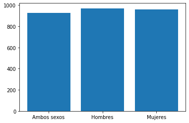

```python
plt.bar(df['Sexo'],df['Total'])
plt.show()
```